# Part II - (Flight Delays And The Causes)

## by (Nyaradzo Majari)

# Flight Delays AND Their Causes

## Investigation Overview

> My main focus is on the relationships between the delays and what mainly caused the flight cancellations.

## Dataset Overview

> This dataset consists scheduled and actual departure and arrival times reported by certified U.S. air carriers, arrival and departure delays, and reasons for delays, from 1987 to 2020. The data is collected by the Office of Airline Information, Bureau of Transportation Statistics (BTS).

### Correlation between the DepDelay and ArrDelay

The relationship is strong and positve between DepDelay and ArrDelay

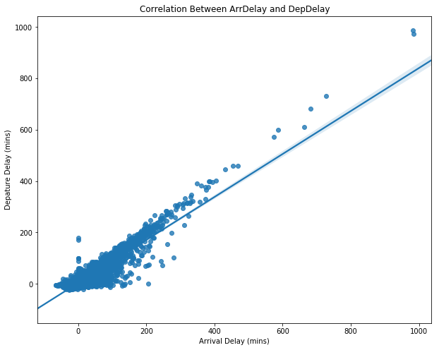

## Monthly distribution of Arrival Delay and Departure Delay

> Both Arrival and Departure delays have a similar pattern. It shows very low value count of delays in February and high value count in August. It then shows that its better to travel during the month of February.

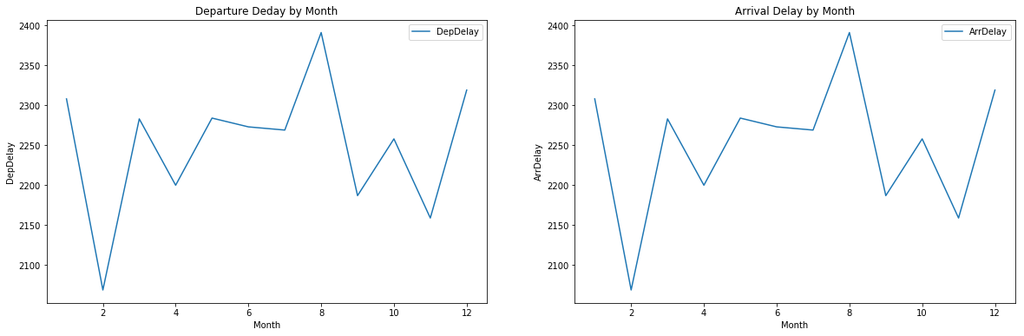

### Checking which delay was popular over the years.

Depature Delay had always been dominant over these years, followed by Arrival Delay only a few times when it interchanged with LateAirCraft Delay.

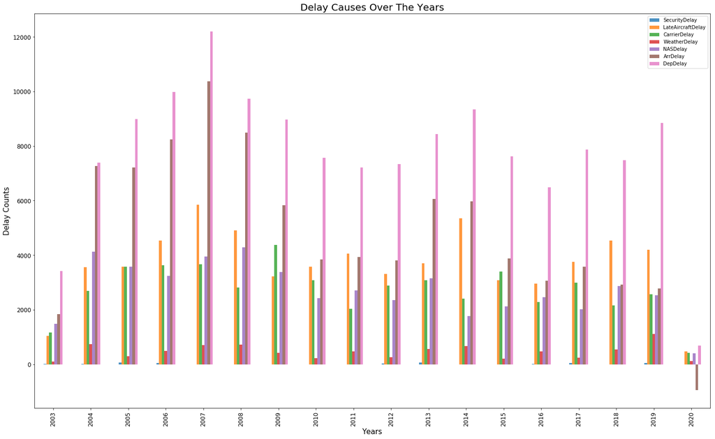

### Yearly flight cancellations

In most of the years Weather(B) had been causing flight cancellations most. Security(D) was never an issue until 2020 where it has the highest figure and it might have been triggered by corona virus.

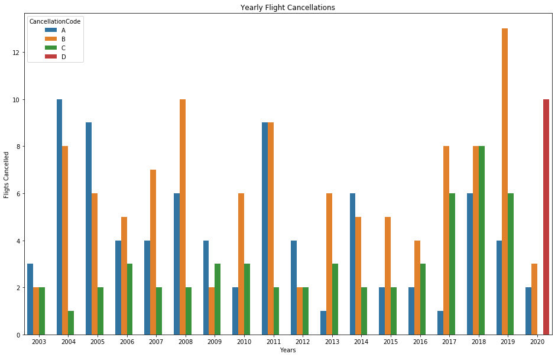